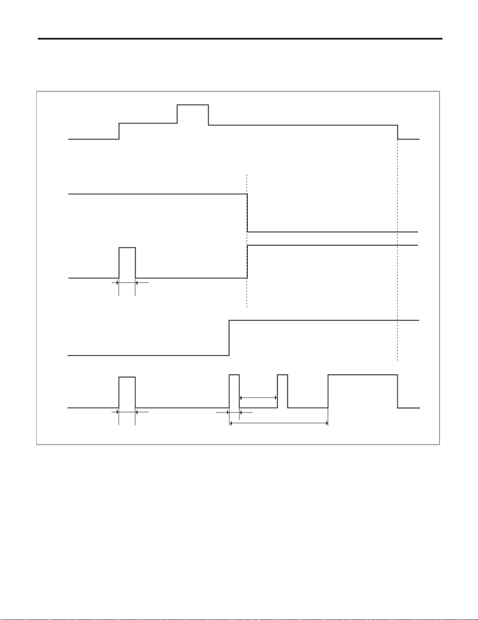

TPM(diag)-17

Tire Pressure Warning Light / Trouble Indicator Light Illumination Pattern

TIRE PRESSURE MONITORING SYSTEM (DIAGNOSTICS)

12.Tire Pressure Warning Light / Trouble Indicator Light Illumination

Pattern

A: INSPECTION

(1) Ignition switch (8) Tire inflation pressure warning

light (pressure condition)

(15) Light OFF

(2) OFF (9) Light OFF (16) Blink

(3) ON (10) Light ON (17) 1 second

(4) Start (11) System status (18) Blinks 25 times

(5) Tire inflation pressure condition (12) Normal (19) 2 seconds

(6) Meet the specification (13) Malfunction

(7) Less than standard value

(For the pressure warning level,

refer to “CURRENT DATA”.) <Ref.

to TPM(diag)-13, LIST, Read Cur-

rent Data.>

(14) Tire inflation pressure warning

light (system condition)

TPM00071

(2)

(3)

(4)

(3)

(5)

(6)

(7)

(8)

(9)

(10)

(2)

(11)

(12)

(13)

(14)

(15)

(16)

(17)

(19)

(10)

(9)

(19)

(1)

(18)

(10)

(19)

[figure not shown]

TPM(diag)-18

Tire Pressure Warning Light / Trouble Indicator Light Illumination Pattern

TIRE PRESSURE MONITORING SYSTEM (DIAGNOSTICS)

1) When the tire pressure warning light does not illuminate in accordance with this illumination pattern, there

must be an electrical malfunction.

2) If the tire pressure warning light does not go off, check the TPMS & keyless entry CM or TPMS CM/warn-

ing light circuit and the combination meter circuit. <Ref. to TPM(diag)-18, TIRE PRESSURE WARNING

LIGHT DOES NOT COME OFF, Tire Pressure Warning Light / Trouble Indicator Light Illumination Pattern.>

NOTE:

If the problem is fixed while driving at approximately 40 km/h (25 MPH) after the tire pressure warning light

blinks/lights, the warning light goes out and the tire pressure monitor system operates normally. (If there is

a decrease in tire pressure, or a malfunction of the system, the malfunction history is displayed.)

B: TIRE PRESSURE WARNING LIGHT DOES NOT COME ON

DETECTING CONDITION:

Defective combination meter

TROUBLE SYMPTOM:

When the ignition switch is turned to ON, the tire pressure warning light does not turn on (for approx. 2 sec-

onds).

C: TIRE PRESSURE WARNING LIGHT DOES NOT COME OFF

DETECTING CONDITION:

• Defective combination meter

• Tires pressure drop

• Transmitter ID not registered

TROUBLE SYMPTOM:

Tire pressure warning light remains illuminating after engine starts.

Step Check Yes No

1 CHECK DIAGNOSTIC TROUBLE CODE

(DTC).

Connect the Subaru Select Monitor, and read

the Diagnostic Trouble Code. <Ref. to

TPM(diag)-11, OPERATION, Read Diagnostic

Trouble Code (DTC).>

Is diagnostics code (DTC) dis-

played?

Perform the diag-

nosis according to

the DTC. <Ref. to

TPM(diag)-21, List

of Diagnostic Trou-

ble Code (DTC).>

Replace the com-

bination meter.

<Ref. to IDI-13,

REMOVAL, Com-

bination Meter.>

Step Check Yes No

1 CHECK DTC.

Connect the Subaru Select Monitor, and read

the Diagnostic Trouble Code. <Ref. to

TPM(diag)-11, OPERATION, Read Diagnostic

Trouble Code (DTC).>

Is a DTC displayed? Perform the diag-

nosis according to

the DTC. <Ref. to

TPM(diag)-21, List

of Diagnostic Trou-

ble Code (DTC).>

Go to step 2.

2 CHECK TRANSMITTER (ID).

Display the transmitter ID of the tire pressure

monitor system.

Is the transmitter ID registered? Go to step 3. Register the trans-

mitter ID. <Ref. to

TPM(diag)-14,

OPERATION,

Register Transmit-

ter (ID).>

3 CHECK TRANSMITTER DATA OUTPUT.

1) Select data display of the tire pressure mon-

itoring.

2) Start the engine and check the tire pressure

warning light output.

Is the warning light output ON? Replace the TPMS

& keyless entry CM

or TPMS CM.

<Ref. to WT-9, Tire

Pressure Monitor-

ing System.>

Replace the com-

bination meter.

<Ref. to IDI-13,

REMOVAL, Com-

bination Meter.>

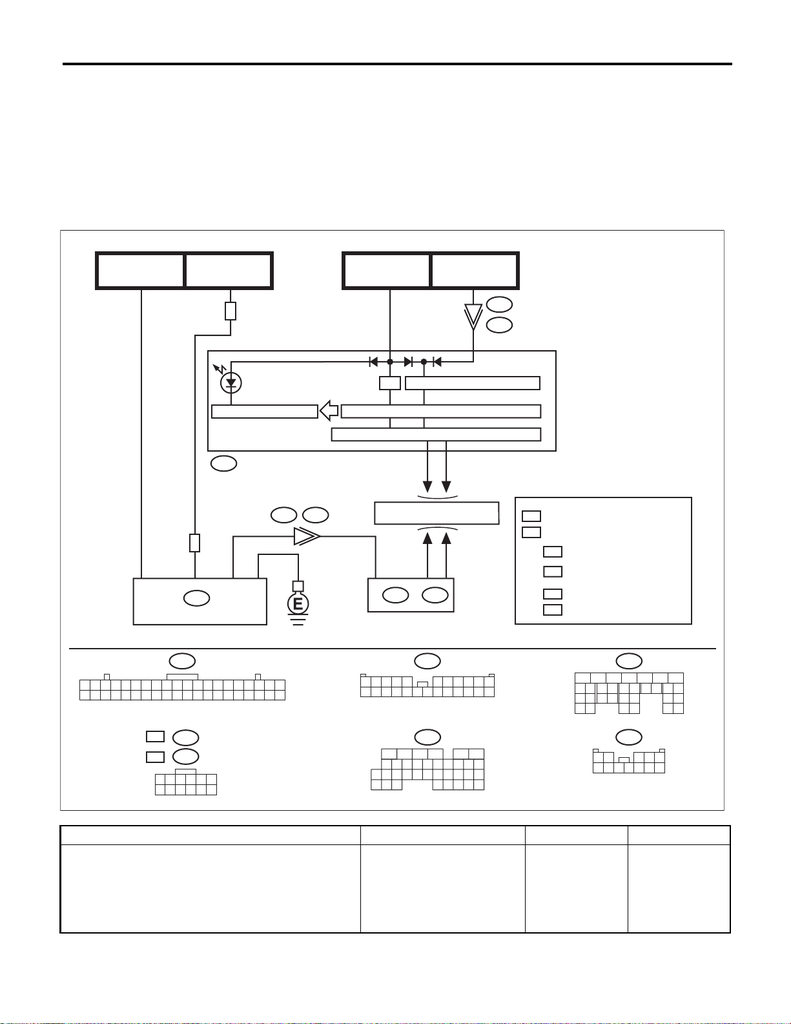

TPM(diag)-19

Tire Pressure Warning Light / Trouble Indicator Light Illumination Pattern

TIRE PRESSURE MONITORING SYSTEM (DIAGNOSTICS)

D: TIRE PRESSURE WARNING LIGHT IS 25 TIMES BLINKING AND TURN ON

DETECTING CONDITION:

• Defective TPMS & keyless entry CM or TPMS CM

• Defective harness

• Transmitter is faulty.

TROUBLE SYMPTOM:

Every time the engine starts, tire pressure warning light blinks 25 times and then illuminates.

WIRING DIAGRAM:

Tire Pressure Monitoring System <Ref. to WI-403, WIRING DIAGRAM, Tire Pressure Monitoring System.>

Step Check Yes No

1 CHECK DTC.

Connect the Subaru Select Monitor, and read

the Diagnostic Trouble Code. <Ref. to

TPM(diag)-11, OPERATION, Read Diagnostic

Trouble Code (DTC).>

Is diagnostics code (DTC) dis-

played?

Perform the diag-

nosis according to

the DTC. <Ref. to

TPM(diag)-21, List

of Diagnostic Trou-

ble Code (DTC).>

Go to step 2.

R221

11 12

9

10

78

65341

2

R211

:

WP

:

OP

i102

10 11

567

i84

19

18

21

20

2322 24 25 26

17

1

23

4

56

27

28 29 30

31 32 33 34 35

798

151413121110 16

C:

i229

11 12

9

10

768

5431

2

i10

11 12

9

10

7856341

2

15 1613 14 19

18

20

21 22 23 24 26

25

17

D:

i171

19

18

20 21

22

23

26

24

25

27

28 29

30 31

98

15

1413121110

17

16

1234567

1

2

1

WP

OP

2

WP

OP

: R211

: R221

OP

WP

3

20

33

32

40

i10

I/F

OP

OP

1

i229

B551

C: i84 i171D:

C35

C27

D11

5

R167

i102

11

4

6

TPM00141

:

:

BODY INTEGRATED UNIT

FB-31

F/B FUSE NO. 4

(IG)

FB-12

F/B FUSE NO. 2

(IG)

FB-11

F/B FUSE NO. 15

(B)

FB-18

F/B FUSE NO. 7

(B)

REF. TO CAN COMMUNICATION

SYSTEM

COMBINATION METER

DRIVE CIRCUIT

POWER SUPPLY CIRCUIT

CAN TRANSCEIVER & RECEIVER

MICRO COMPUTER

TIRE INFLATION

PRESSURE

WARNING LIGHT

: WITH KEYLESS ACCESS

: WITHOUT KEYLESS ACCESS

: TPMS CM

: TPMS & KEYLESS ENTRY CM

[figure not shown]

TPM(diag)-20

Tire Pressure Warning Light / Trouble Indicator Light Illumination Pattern

TIRE PRESSURE MONITORING SYSTEM (DIAGNOSTICS)

2 CHECK LAN COMMUNICATION.

Inspect LAN system. <Ref. to LAN(diag)-2,

PROCEDURE, Basic Diagnostic Procedure.>

Is there any fault? Repair it according

to the diagnosis for

LAN system.

Go to step 3.

3 CHECK HARNESS.

Measure the resistance between TPMS & key-

less entry CM or TPMS CM and body integrated

unit.

Connector & terminal

Without keyless access

(R221) No. 11 — (i171) No. 11:

With keyless access

(R211) No. 11 — (i171) No. 11:

Is the resistance less than 10

Ω?

Go to step 4. Repair the har-

ness.

4 CHECK CONNECTOR.

Check each connector.

Is there poor contact or any

other faults?

Repair the connec-

tor.

Replace the TPMS

& keyless entry CM

or TPMS CM.

<Ref. to WT-9, Tire

Pressure Monitor-

ing System.>